# Practical Machine Learning Assignment

# Introduction

Data from three smart devices the Jawbone Up, the Nike FuelBand, and the Fitbit were collected from a group of 6 individuals performing one exercise correctly and incorrectly. In this assignment I will try to build a prediction model that predicts how correctly or not the exercise is perrformed based on measurements collected from such devices.

```r
library(caret)
```

```r
library(rpart)
library(rpart.plot)
library(e1071)
library(randomForest)
library(gbm)
```

## Loading of the training and test raw data

```r
traindata_raw <- read.csv("https://d396qusza40orc.cloudfront.net/predmachlearn/pml-training.csv")
testdata_raw <- read.csv("https://d396qusza40orc.cloudfront.net/predmachlearn/pml-testing.csv")
```

## A) Cleaning the data

A.1 Removing columns that are mostly NA

```r
na_cols <- sapply(traindata_raw, function(x) mean(is.na(x)) > 0.95)
training <- traindata_raw[,na_cols==FALSE]
testing  <- testdata_raw[,na_cols==FALSE]
```

A.2 Removing columns that have zero variance, since they are non-informative

```r
zero_var_cols <- nearZeroVar(training)
training <- training[, -zero_var_cols]
testing  <- testing[, -zero_var_cols]

names(training)
```

```
##  [1] "X"                    "user_name"            "raw_timestamp_part_1"
##  [4] "raw_timestamp_part_2" "cvtd_timestamp"       "num_window"
##  [7] "roll_belt"            "pitch_belt"           "yaw_belt"
## [10] "total_accel_belt"     "gyros_belt_x"         "gyros_belt_y"
## [13] "gyros_belt_z"         "accel_belt_x"         "accel_belt_y"
## [16] "accel_belt_z"         "magnet_belt_x"        "magnet_belt_y"
## [19] "magnet_belt_z"        "roll_arm"             "pitch_arm"
## [22] "yaw_arm"              "total_accel_arm"      "gyros_arm_x"
## [25] "gyros_arm_y"          "gyros_arm_z"          "accel_arm_x"
## [28] "accel_arm_y"          "accel_arm_z"          "magnet_arm_x"
## [31] "magnet_arm_y"         "magnet_arm_z"         "roll_dumbbell"
## [34] "pitch_dumbbell"       "yaw_dumbbell"         "total_accel_dumbbell"
## [37] "gyros_dumbbell_x"     "gyros_dumbbell_y"     "gyros_dumbbell_z"
## [40] "accel_dumbbell_x"     "accel_dumbbell_y"     "accel_dumbbell_z"
## [43] "magnet_dumbbell_x"    "magnet_dumbbell_y"    "magnet_dumbbell_z"
## [46] "roll_forearm"         "pitch_forearm"        "yaw_forearm"
## [49] "total_accel_forearm"  "gyros_forearm_x"      "gyros_forearm_y"
## [52] "gyros_forearm_z"      "accel_forearm_x"      "accel_forearm_y"
## [55] "accel_forearm_z"      "magnet_forearm_x"     "magnet_forearm_y"
## [58] "magnet_forearm_z"     "classe"
```

```r
training <- training[,8:length(training)]
testing  <- testing[,8:length(testing)]

dim(training); dim(testing)
```

```
## [1] 19622    52
```

```
## [1] 20 52
```

## B) Data Particioning

The training data set is a large data set, 40% of this will be used for cross-validation within another smaller testing set.

```r
set.seed(3324)
intrain <- createDataPartition(training$classe, p=0.6, list=FALSE)
subtraining <- training[intrain,]
subtesting <- training[-intrain,]
```

## C) Building the Prediction Model

For the prediction model 3 algorithms will be used, namely the Random Forest, the Decision Tree Model and the Gradient Boosting Model. Their accuracy will be checked for the subtesting data set and then the model with the best accuracy will be selected for the final test.

#### C.1 Random Forest

Model fit for the random forest algorithm on the sub-training test.

```r
set.seed(3324)
modfit_rf <- train(classe~., method ='rf', data = subtraining, ntree = 100)
```

Creating the prediction model with the sub-testing data set.

```r
predict_rf <- predict(modfit_rf, subtesting)

RF_confmatr <- confusionMatrix(predict_rf, subtesting$classe)
RF_confmatr
```

```
## Confusion Matrix and Statistics
##
##           Reference
## Prediction    A    B    C    D    E
##          A 2231   15    0    0    0
##          B    1 1492    7    1    0
##          C    0   11 1356   10    4
##          D    0    0    5 1273    5
##          E    0    0    0    2 1433
##
## Overall Statistics
##
##                Accuracy : 0.9922
##                  95% CI : (0.99, 0.994)
##     No Information Rate : 0.2845
##     P-Value [Acc > NIR] : < 2.2e-16
##
##                   Kappa : 0.9902
##
##  Mcnemar's Test P-Value : NA
##
## Statistics by Class:
##
##                      Class: A Class: B Class: C Class: D Class: E
## Sensitivity            0.9996   0.9829   0.9912   0.9899   0.9938
## Specificity            0.9973   0.9986   0.9961   0.9985   0.9997
## Pos Pred Value         0.9933   0.9940   0.9819   0.9922   0.9986
## Neg Pred Value         0.9998   0.9959   0.9981   0.9980   0.9986
## Prevalence             0.2845   0.1935   0.1744   0.1639   0.1838
## Detection Rate         0.2843   0.1902   0.1728   0.1622   0.1826
## Detection Prevalence   0.2863   0.1913   0.1760   0.1635   0.1829
## Balanced Accuracy      0.9984   0.9907   0.9937   0.9942   0.9967
```

The accuracy of the random forest algorithm on this test data set is around 99%, which is considered very good.

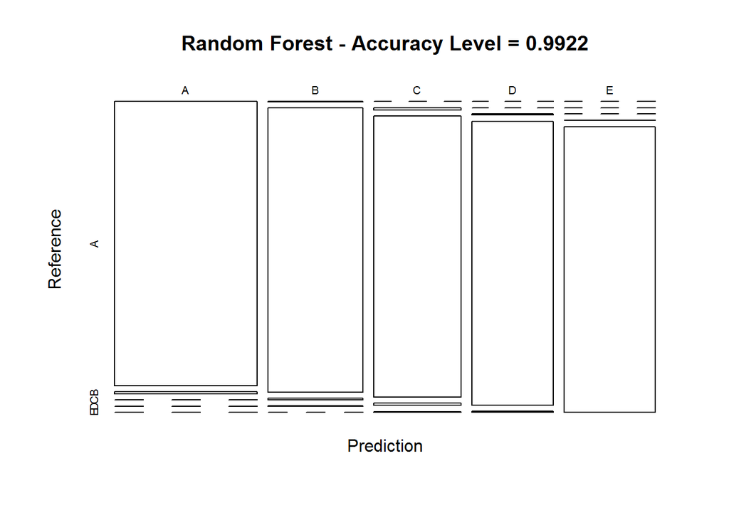

#### C.2 Decision Tree Model

Model fit with the decision tree algorithm on the sub-training test.

```r
set.seed(873)
modfit_dtm <- train(classe~., method ='rpart', data = subtraining)
```

Creating the prediction model with the sub-testing data set.

```r
predict_dtm <- predict(modfit_dtm, subtesting)
DTM_confmatr <- confusionMatrix(predict_dtm, subtesting$classe)

DTM_confmatr
```

```
## Confusion Matrix and Statistics
##
##           Reference
## Prediction    A    B    C    D    E
##          A 2047  622  653  565  339
##          B   36  515   37  242  287
##          C   96  176  571  198  195
##          D   51  205  107  281  193
##          E    2    0    0    0  428
##
## Overall Statistics
##
##                Accuracy : 0.4897
##                  95% CI : (0.4786, 0.5008)
##     No Information Rate : 0.2845
##     P-Value [Acc > NIR] : < 2.2e-16
##
##                   Kappa : 0.3322
##
##  Mcnemar's Test P-Value : < 2.2e-16
##
## Statistics by Class:
##
##                      Class: A Class: B Class: C Class: D Class: E
## Sensitivity            0.9171  0.33926  0.41740  0.21851  0.29681
## Specificity            0.6119  0.90487  0.89734  0.91524  0.99969
## Pos Pred Value         0.4844  0.46106  0.46197  0.33572  0.99535
## Neg Pred Value         0.9489  0.85094  0.87943  0.85661  0.86327
## Prevalence             0.2845  0.19347  0.17436  0.16391  0.18379
## Detection Rate         0.2609  0.06564  0.07278  0.03581  0.05455
## Detection Prevalence   0.5386  0.14237  0.15753  0.10668  0.05480
## Balanced Accuracy      0.7645  0.62206  0.65737  0.56688  0.64825
```

The accuracy of the decision tree algorithm on this test data set is around 49%, which is not considered good enough.

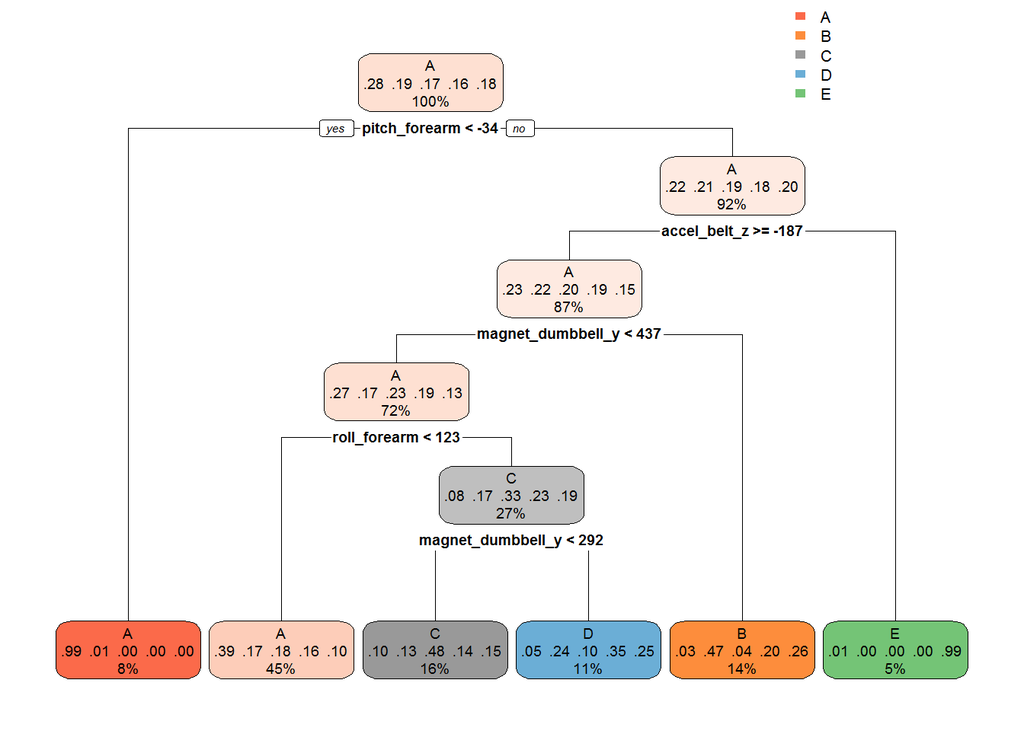

#### C.3 Gradient Boosting Model

Model fit with the gradient boosting model algorithm on the sub-training test.

```r
set.seed(1007)
modfit_gbm <- train(classe~., method ='gbm', data = subtraining, verbose=FALSE)
```

Creating the prediction model with the sub-testing data set.

```r
predict_gbm <- predict(modfit_gbm, subtesting)
GBM_confmatr <- confusionMatrix(predict_gbm, subtesting$classe)

GBM_confmatr
```

```
## Confusion Matrix and Statistics
##
##           Reference
## Prediction    A    B    C    D    E
##          A 2196   44    0    3    3
##          B   22 1424   33    7   12
##          C   10   47 1317   36   13
##          D    4    1   15 1223   16
##          E    0    2    3   17 1398
##
## Overall Statistics
##
##                Accuracy : 0.9633
##                  95% CI : (0.9589, 0.9673)
##     No Information Rate : 0.2845
##     P-Value [Acc > NIR] : < 2.2e-16
##
##                   Kappa : 0.9536
##
##  Mcnemar's Test P-Value : 3.303e-07
##
## Statistics by Class:
##
##                      Class: A Class: B Class: C Class: D Class: E
## Sensitivity            0.9839   0.9381   0.9627   0.9510   0.9695
## Specificity            0.9911   0.9883   0.9836   0.9945   0.9966
## Pos Pred Value         0.9777   0.9506   0.9255   0.9714   0.9845
## Neg Pred Value         0.9936   0.9852   0.9921   0.9904   0.9932
## Prevalence             0.2845   0.1935   0.1744   0.1639   0.1838
## Detection Rate         0.2799   0.1815   0.1679   0.1559   0.1782
## Detection Prevalence   0.2863   0.1909   0.1814   0.1605   0.1810
## Balanced Accuracy      0.9875   0.9632   0.9732   0.9728   0.9830
```

The accuracy of the gradient boosting model algorithm on this test data set is around 96%, which is as expected very close to the random forest one.

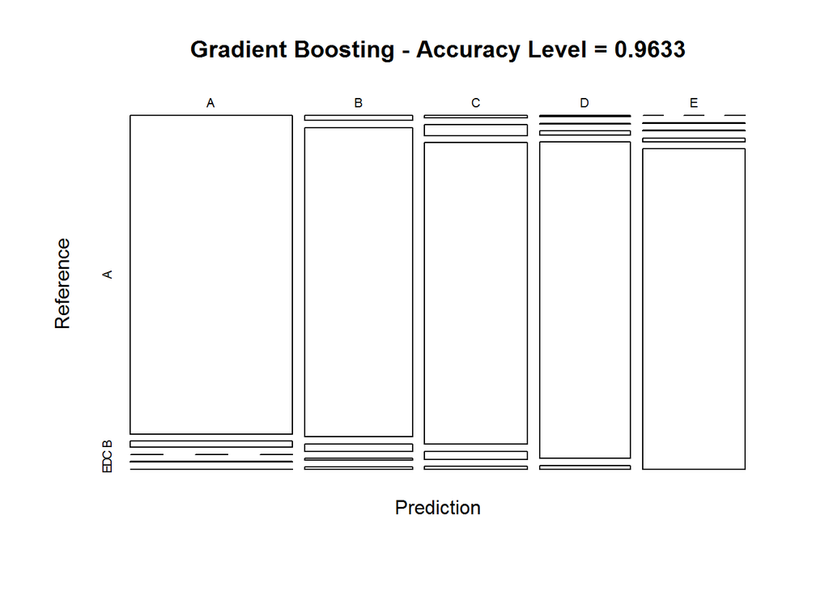

# D) Coclusion and Application of the Algorithm on main Test data set.

From the above analysis it is clear that the random forest algorithm gives the highest accuracy, which is in line with common industry practice. The prediction model used with the random forest alogrithm is utilised below on the full test data set.

```r
final_prediction <- predict(modfit_rf, testing)
final_prediction
```

```
##  [1] B A B A A E D B A A B C B A E E A B B B
## Levels: A B C D E
```